# Homework_02

brennastallings

9/16/2019

This is for [Homework 2](https://fuzzyatelin.github.io/bioanth-stats/homework-02.html)of AN597 for Modules 6&7.

Question 1

> Every Saturday morning, at the same time, a primatologist goes and sits in the forest to listen for titi monkey calls, counting the number of calls they hear in a 2 hour window from 5am to 7am. Based on previous knowledge, she believes that the mean number of calls she will hear in that time is exactly 15. Let X represent the appropriate Poisson random variable of the number of calls heard in each monitoring session.

P(x; λ) = (e-λ) (λx) / x! λ=15 e = 2.71828

```r
ppois(q=7, lambda = 15, lower.tail = FALSE)
```

```
## [1] 0.9819978
```

```r
#q is 7, because with lower.tail=FALSE, the P[X > x], so to include 8, q=7
```

What is the probability that she will hear no calls in a session?

```r
##probabilty where x=0
dpois(x=0, lambda=15)
```

```
## [1] 3.059023e-07
```

What is the probability that she will hear exactly 3 calls in a session?

```r
##probability where x=3
dpois(x=3, lambda=15)
```

```
## [1] 0.0001720701
```

Plot the relevant Poisson mass function over the values in range 0 ≤ x ≤ 30.

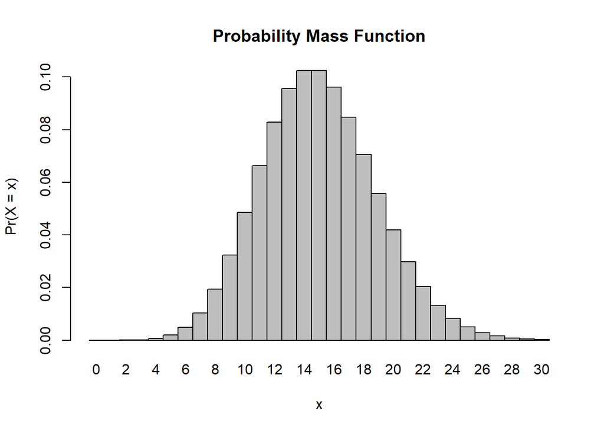

```r
x <- 0:30
l = 15
probset<-dpois(x=x,lambda=l)
barplot(probset,names.arg=x,space=0,xlab="x",ylab="Pr(X = x)",main="Probability Mass Function")
```

Simulate 104 results from this distribution (i.e., 2 years of Saturday monitoring sessions).

```r
x<-c(0:30)
l = 15
probset<-dpois(x=c(1:30),lambda=l)
#gives the probabilty of each # in the vector 1:30
ncall<-104
Saturdays <- function(x) {
  sample(1:30, x, replace=TRUE, prob = probset)
#not sure I can sample from Probset
  }
twoyear<-Saturdays(ncall)

#prob= tells the fxn to find the probability of each of the #s 1:30 in the vector called probset
```

Plot the simulated results using hist() and use xlim() to set the horizontal limits to be from 0 to 30.

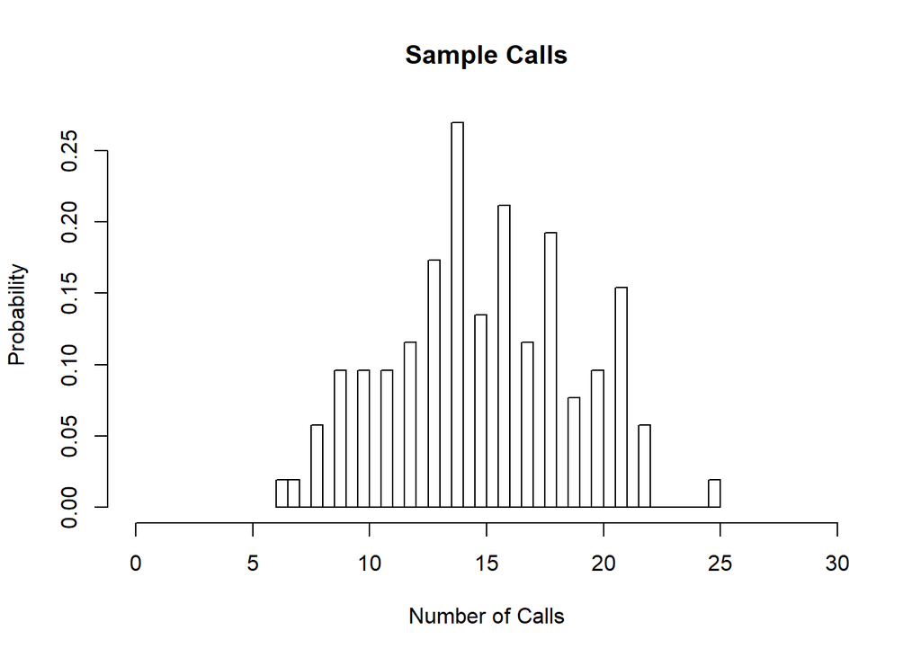

#How does your histogram compare to the shape of the probability mass function you plotted above?

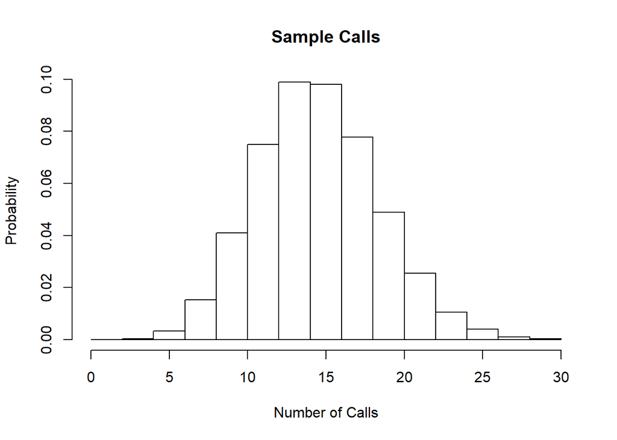

>5 Challenges

1. I tried to use the dpois function when I needed to use the ppois function
2. I thought that I had a functioning code for the first question but it was only because I hadnt cleared out the environment so it was using variables I didnt actually have defined.
3. I couldnt get the code for the final question to work. My graph wasnt properly taking the probabilites from the Poisson into account.
4. I was having the final function sample from the probabilities from the Poisson instead of the numbers in it.
5. I cannot get the bins in my final graph to match the bins in the mass function that we had made before.